# Credit Scoring

Data Analysis Step

Felipe Daiha Alves

2022-08-13

# 1 . **Objetivo**:

Relatório da etapa de *data analysis* contendo informações e resultados sobre o processo de **Risco de Crédito** em empréstimos bancários.

O conjunto de dados original foi extraído de uma fonte pública e salvo localmente em um *csv* para análise. Para acesso ao dicionário das variáveis, entre em https://github.com/daiha98/credit_scoring/blob/main/README.md.

# 2 . **Environment & Data Cleaning**:

## 2.1 . **Configurando Ambiente**

```r
# Nome dos pacotes

packages <- c('dplyr', 'tidyr', 'data.table', ## Manipulacao de Dados
              'ggplot2', 'gridExtra', 'scales', 'ggcorrplot' ## Visualizacao de Dados
              )


# Instalando pacotes (caso ainda nao esteja)

installed_packages <- packages %in% rownames(installed.packages())
if (any(installed_packages == FALSE)) {
  install.packages(packages[!installed_packages])
}


# Carregando pacotes

invisible(lapply(packages, library, character.only = TRUE))


# Removendo variavel criada previamente

rm(packages, installed_packages)


# Configuracoes de visualizacao

options(digits = 10, scipen = 999)
```

## 2.2 . **Carregando dados**

```r
# Load da base de dados

CreditScoring <- data.table::fread('C:/Users/daiha/OneDrive/Desktop/Cursos/Kaggle/CreditScoring.csv', drop = 'V1')


# Visualizacao primaria dos dados

glimpse(CreditScoring)
```

```
## Rows: 40,000
## Columns: 28
## $ clientId                             <int> 2, 4, 5, 6, 7, 8, 9, 10, 11, 12, …
## $ shopId                               <int> 15, 12, 16, 24, 55, 6, 3, 23, 25,…
## $ gender                               <chr> "F", "F", "F", "M", "F", "F", "F"…
## $ maritalStatus                        <chr> "S", "C", "S", "S", "S", "C", "S"…
## $ age                                  <int> 18, 47, 28, 26, 22, 21, 27, 57, 5…
## $ numberOfDependents                   <int> 0, 0, 0, 0, 0, 0, 0, 0, 0, 0, 0, …
## $ education                            <lgl> NA, NA, NA, NA, NA, NA, NA, NA, N…
## $ flagResidencialPhone                 <chr> "Y", "N", "Y", "N", "Y", "Y", "Y"…
## $ areaCodeResidencialPhone             <int> 31, 31, 31, 31, 31, 23, 31, 31, 3…
## $ bestPaymentDay                       <int> 20, 25, 25, 28, 12, 28, 20, 12, 1…
## $ shopRank                             <int> 0, 0, 0, 0, 0, 0, 0, 0, 0, 0, 0, …
## $ residenceType                        <chr> "P", "P", "O", "P", "A", "A", "A"…
## $ monthsInResidence                    <int> 216, 180, 12, 180, 0, 24, 0, 24, …
## $ flagMothersName                      <chr> "Y", "Y", "Y", "Y", "Y", "Y", "Y"…
## $ flagFathersName                      <chr> "Y", "Y", "Y", "Y", "Y", "Y", "Y"…
## $ flagResidenceTown_WorkingTown        <chr> "Y", "N", "Y", "N", "Y", "Y", "Y"…
## $ flagResidenceState_WorkingState      <chr> "Y", "Y", "Y", "Y", "Y", "Y", "Y"…
## $ monthsInTheJob                       <int> 12, 24, 12, 0, 48, 12, 0, 96, 24,…
## $ professionCode                       <int> 853, 35, 24, 999, 999, 40, 950, 1…
## $ mateIncome                           <dbl> 0, 0, 0, 0, 0, 800, 0, 0, 0, 0, 0…
## $ flagResidencialAddress_PostalAddress <chr> "Y", "Y", "Y", "Y", "Y", "Y", "Y"…
## $ flagOtherCard                        <chr> "N", "N", "N", "N", "N", "N", "N"…
## $ quantityBankingAccounts              <int> 0, 0, 0, 0, 0, 0, 0, 0, 0, 0, 0, …
## $ flagMobilePhone                      <chr> "N", "N", "N", "N", "N", "N", "N"…
## $ flagContactPhone                     <chr> "N", "N", "N", "N", "N", "N", "N"…
## $ personalNetIncome                    <dbl> 300, 304, 250, 800, 410, 248, 100…
## $ codeApplicationBooth                 <int> 0, 0, 0, 0, 0, 0, 0, 0, 0, 0, 0, …
## $ BAD                                  <int> 0, 0, 0, 0, 0, 0, 1, 0, 1, 0, 0, …
```

**Convertendo tipo de variáveis necessárias**

```r
# Convertendo classes de forma funcional para determinadas variaveis

CreditScoring <- CreditScoring %>%
  dplyr::mutate(dplyr::across(c(clientId, shopId, areaCodeResidencialPhone,
                                shopRank, professionCode, codeApplicationBooth),
                              ~as.character(.x)))

# Verificando alteracoes

lapply(CreditScoring, class)
```

```
## $clientId
## [1] "character"
##
## $shopId
## [1] "character"
##
## $gender
## [1] "character"
##
## $maritalStatus
## [1] "character"
##
## $age
## [1] "integer"
##
## $numberOfDependents
## [1] "integer"
##
## $education
## [1] "logical"
##
## $flagResidencialPhone
## [1] "character"
##
## $areaCodeResidencialPhone
## [1] "character"
##
## $bestPaymentDay
## [1] "integer"
##
## $shopRank
## [1] "character"
##
## $residenceType
## [1] "character"
##
## $monthsInResidence
## [1] "integer"
##
## $flagMothersName
```

[output cut: 28 more lines]

```
##
## $flagMobilePhone
## [1] "character"
##
## $flagContactPhone
## [1] "character"
##
## $personalNetIncome
## [1] "numeric"
##
## $codeApplicationBooth
## [1] "character"
##
## $BAD
## [1] "integer"
```

## 2.3 . **Breve visualização dos Dados**

**Sumário Estatístico**

```r
# Estatisticas basicas para verificacao de intervalos e inconsistencias

summary(CreditScoring)
```

```
##    clientId            shopId             gender          maritalStatus
##  Length:40000       Length:40000       Length:40000       Length:40000
##  Class :character   Class :character   Class :character   Class :character
##  Mode  :character   Mode  :character   Mode  :character   Mode  :character
##
##
##
##       age           numberOfDependents education      flagResidencialPhone
##  Min.   :15.00000   Min.   :0          Mode:logical   Length:40000
##  1st Qu.:23.00000   1st Qu.:0          NA's:40000     Class :character
##  Median :33.00000   Median :0                         Mode  :character
##  Mean   :34.64972   Mean   :0
##  3rd Qu.:43.00000   3rd Qu.:0
##  Max.   :88.00000   Max.   :0
##  areaCodeResidencialPhone bestPaymentDay       shopRank
##  Length:40000             Min.   : 1.00000   Length:40000
##  Class :character         1st Qu.: 9.00000   Class :character
##  Mode  :character         Median :12.00000   Mode  :character
##                           Mean   :15.31395
##                           3rd Qu.:20.00000
##                           Max.   :28.00000
##  residenceType      monthsInResidence   flagMothersName    flagFathersName
##  Length:40000       Min.   :   0.0000   Length:40000       Length:40000
##  Class :character   1st Qu.:  36.0000   Class :character   Class :character
##  Mode  :character   Median : 120.0000   Mode  :character   Mode  :character
##                     Mean   : 152.9211
##                     3rd Qu.: 240.0000
##                     Max.   :1188.0000
##  flagResidenceTown_WorkingTown flagResidenceState_WorkingState
##  Length:40000                  Length:40000
##  Class :character              Class :character
##  Mode  :character              Mode  :character
##
##
##
##  monthsInTheJob      professionCode       mateIncome
##  Min.   :   0.0000   Length:40000       Min.   :    0.00000
##  1st Qu.:  12.0000   Class :character   1st Qu.:    0.00000
##  Median :  24.0000   Mode  :character   Median :    0.00000
##  Mean   :  50.6295                      Mean   :   50.99333
```

[output cut: 8 more lines]

```
##
##  quantityBankingAccounts flagMobilePhone    flagContactPhone
##  Min.   :0               Length:40000       Length:40000
##  1st Qu.:0               Class :character   Class :character
##  Median :0               Mode  :character   Mode  :character
##  Mean   :0
##  3rd Qu.:0
##  Max.   :0
##  personalNetIncome     codeApplicationBooth      BAD
##  Min.   :       0.00   Length:40000         Min.   :0.0000
##  1st Qu.:     270.00   Class :character     1st Qu.:0.0000
##  Median :     400.00   Mode  :character     Median :0.0000
##  Mean   :    9752.71                        Mean   :0.1975
##  3rd Qu.:     738.00                        3rd Qu.:0.0000
##  Max.   :38529098.00                        Max.   :1.0000
```

**Analisando NAs**

```r
# Checando NAs na base

sapply(CreditScoring, function(x) sum(is.na(x)))
```

```
##                             clientId                               shopId
##                                    0                                    0
##                               gender                        maritalStatus
##                                    0                                    0
##                                  age                   numberOfDependents
##                                    0                                    0
##                            education                 flagResidencialPhone
##                                40000                                    0
##             areaCodeResidencialPhone                       bestPaymentDay
##                                    0                                    0
##                             shopRank                        residenceType
##                                    0                                    0
##                    monthsInResidence                      flagMothersName
##                                    0                                    0
##                      flagFathersName        flagResidenceTown_WorkingTown
##                                    0                                    0
##      flagResidenceState_WorkingState                       monthsInTheJob
##                                    0                                    0
##                       professionCode                           mateIncome
##                                    0                                    0
## flagResidencialAddress_PostalAddress                        flagOtherCard
##                                    0                                    0
##              quantityBankingAccounts                      flagMobilePhone
##                                    0                                    0
##                     flagContactPhone                    personalNetIncome
##                                    0                                    0
##                 codeApplicationBooth                                  BAD
##                                    0                                    0
```

**Checando Classes**

```r
# Verificando classes de algumas variaveis

lapply(CreditScoring %>%
         dplyr::select(gender, maritalStatus, flagResidencialPhone,
                       areaCodeResidencialPhone, bestPaymentDay, shopRank, residenceType,
                       flagMothersName, flagFathersName, flagResidenceTown_WorkingTown,
                       flagResidenceState_WorkingState, professionCode,
                       flagResidencialAddress_PostalAddress, flagOtherCard,
                       flagMobilePhone, flagContactPhone, codeApplicationBooth, BAD),
       table)
```

```
## $gender
##
##           F     M
##     3 27903 12094
##
## $maritalStatus
##
##     C     D     O     S     V
## 13721  1723  2220 20375  1961
##
## $flagResidencialPhone
##
##     N     Y
##  7351 32649
##
## $areaCodeResidencialPhone
##
##     1    10    11    12    13    14    15    17    19     2    21    22    23
##     2     1     6     2     1     1     1     1     1     3     1     1   793
##    24    25    26    27     3    30    31    32    33    34    35    36    37
##    90     1     3    20     1     1 28080    26     4     2     1     1     2
##    38    39     4    40    41    42    43    44    45    46    47    48    49
##    10     1     1     1     2    12     4     1     1     1     1     2    37
##     5    50    51    52    56    57    59     6    60    62    63    64    65
##  1951  8884     1     9     8     2     1     2     1     1     1     1     1
##    67    68    69     7    70     8     9
##     2     6     2     2     1     3     1
##
## $bestPaymentDay
##
##     1     3     6     8     9    11    12    15    16    18    20    22    23
##  1091  1563   124  7206   104   213 10150     1   213  6638  5050   127  1157
##    25    27    28
##  2705    54  3604
##
## $shopRank
##
##     0     2     3
## 39770    52   178
##
```

[output cut: 80 more lines]

```
##
## $flagContactPhone
##
##     N
## 40000
##
## $codeApplicationBooth
##
##     0
## 40000
##
## $BAD
##
##     0     1
## 32100  7900
```

*Comments*: Observando brevemente esse db, alguns destaques para tratamento de valores chamam a atenção:  
a) Há 3 registros da variavel ‘gender’ com valores ” “.  
b) Todos os registros de ‘numberOfDependents’, ‘quantityBankingAccounts’ e ‘codeApplicationBooth’ equivalem a 0.  
c) Todos os registros de ‘education’ são NA.  
d) A média do ‘melhor dia de pagamento ’bestPaymentDay’ converge para o meio do mês.  
e) Há demasiados registros com valor 0 em ‘shopRank’.  
f) Há uma predominância da classe Y em ‘flagMothersName’, ‘flagFathersName’ e ‘flagResidenceState_WorkingState’.  
g) Todos os registros de ‘flagOtherCard’, ‘flagMobilePhone’ e ‘flagContactPhone’ são N.  
h) O target está desbalanceado! A maioria dos valores são 0.  
Dessa forma, iremos inicialmente tratar a variável *gender* e dropar features que só apresentam uma única classe/valor ou NA em sua totalidade, visto que são irrelevantes para discriminação do target. Ao final, analisaremos a dimensão que restou do dataset.

```r
# Tratando casos concluidos anteriormente

CreditScoring <- CreditScoring %>%
  dplyr::mutate(gender = ifelse(gender == "", "O", gender)) %>%
        ### Caso gender seja vazio, incluir como classe 'O' de outros
  dplyr::select(!c(numberOfDependents, quantityBankingAccounts, codeApplicationBooth, education,
                   flagOtherCard, flagMobilePhone, flagContactPhone)) ### Retirando colunas indesejadas

# Verificando a dimensao do nosso novo dataset

dim(CreditScoring)
```

```
## [1] 40000    21
```

## 2.4 . **Tratamento de Outliers**

Ao analisar os dados do sumário estatístico, verificamos que algumas variáveis numéricas apresentam *outliers*. Vamos tratar esses valores individualmente

**1 - Variável ‘Age’**

```r
# Filtrando pessoas com idade menor que 18 anos ou maior que 75 anos

ageOut <- CreditScoring %>%
  dplyr::filter(age < 18 | age > 75)


# Printando o quanto essas pessoas representa da totalidade da base

cat(paste0("O número de pessoas com idade inferior a 18 anos é de: ", nrow(ageOut[age<18]), "\n",
           "Enquanto o número de pessoas maior que 75 anos é de: ", nrow(ageOut[age>75]), "\n",
           "Totalizando ", nrow(ageOut), "\n\n",
           "O que representa um percentual de: ",
           round(nrow(ageOut)/nrow(CreditScoring), digits = 4) * 100.00, ' %'))
```

```
## O número de pessoas com idade inferior a 18 anos é de: 89
## Enquanto o número de pessoas maior que 75 anos é de: 92
## Totalizando 181
##
## O que representa um percentual de: 0.45 %
```

**2 - Variável ‘monthsInResidence’**

```r
# Verificando monthsInResidence superior à idade

mIR_out <- CreditScoring %>%
  dplyr::mutate(agesInResidence = monthsInResidence/12) %>%
  dplyr::filter(age < agesInResidence)


# Printando o quanto essas pessoas representa da totalidade da base

cat(paste0("O número de pessoas com anos na residência superior a idade é de: ", nrow(mIR_out), "\n\n",
           "O que representa um percentual de: ",
           round(nrow(mIR_out)/nrow(CreditScoring), digits = 4) * 100.00, ' %'))
```

```
## O número de pessoas com anos na residência superior a idade é de: 806
##
## O que representa um percentual de: 2.02 %
```

*Comments*: Podemos verificar que alguns registros mostram que o número de anos na residência é superior a idade da pessoa, o que na prática é impossível de acontecer. Nesses casos, iremos dropar estes registros, pois podem configurar eventuais casos de fraude financeira ou tentativa de obter melhores condições na análise de crédito.

**3 - Variável ‘monthsInTheJob’**

```r
# Verificando registros onde a idade subtraida da quantidade de anos no trabalho (monthsInTheJob/12) seja menor que 16 anos

mITJ_out <- CreditScoring %>%
  dplyr::mutate(agesInTheJob = monthsInTheJob/12) %>%
  dplyr::filter(age - agesInTheJob < 16)


# Printando o quanto essas pessoas representa da totalidade da base

cat(paste0(
  "O número de pessoas onde a idade subtraida da quantidade de anos no trabalho seja menor que 16 anos é de: ",
  nrow(mITJ_out), "\n\n",
  "O que representa um percentual de: ",
  round(nrow(mITJ_out)/nrow(CreditScoring), digits = 4) * 100.00, ' %'))
```

```
## O número de pessoas onde a idade subtraida da quantidade de anos no trabalho seja menor que 16 anos é de: 803
##
## O que representa um percentual de: 2.01 %
```

*Comments*: Assim como em ‘monthsInResidence’, pode-se analisar que alguns casos apresentam pessoas cujo tempo no trabalho atual apresenta uma diferença muito pequena em relação à idade. O que isso quer dizer? Se analisarmos casos onde uma pessoa tem 25 anos de idade e 18 anos no atual emprego, então a pessoa começou a trabalhar com 7 anos de idade? Isso é praticamente impossível.  
Neste caso, também iremos dropar estes registros, sob a mesma ótica do tempo de vivência em meses na residência atual.

**4 - Variável ‘mateIncome e personalNetIncome’**

```r
# Verificando casos onde rendas sejam superior a 0

    ## 1 - mateIncome

    CreditScoring %>%
      dplyr::mutate(dataset = 'original',
                    total = n()) %>%
      dplyr::group_by(dataset, total) %>%
      dplyr::summarise(flag_mateIncome = ifelse(mateIncome == 0, 0, 1)) %>%
      dplyr::ungroup() %>%
      dplyr::group_by(flag_mateIncome, total) %>%
      dplyr::summarise(obsMateIncome = n()) %>%
      dplyr::ungroup() %>%
      dplyr::mutate(shareMateIncome = paste0(round(obsMateIncome/total, digits = 4) * 100.00, ' %'))
```

```
## # A tibble: 2 × 4
##   flag_mateIncome total obsMateIncome shareMateIncome
##             <dbl> <int>         <int> <chr>
## 1               0 40000         38411 96.03 %
## 2               1 40000          1589 3.97 %
```

```r
    ## 2 - personalNetIncome

    CreditScoring %>%
      dplyr::mutate(dataset = 'original',
                    total = n()) %>%
      dplyr::group_by(dataset, total) %>%
      dplyr::summarise(flag_personalNetIncome = ifelse(personalNetIncome == 0, 0, 1)) %>%
      dplyr::ungroup() %>%
      dplyr::group_by(flag_personalNetIncome, total) %>%
      dplyr::summarise(obspersonalNetIncome = n()) %>%
      dplyr::ungroup() %>%
      dplyr::mutate(sharePersonalNetIncome = paste0(round(obspersonalNetIncome/total, digits = 4) * 100.00, ' %'))
```

```
## # A tibble: 2 × 4
##   flag_personalNetIncome total obspersonalNetIncome sharePersonalNetIncome
##                    <dbl> <int>                <int> <chr>
## 1                      0 40000                  956 2.39 %
## 2                      1 40000                39044 97.61 %
```

*Comments*: Para as variáveis de renda, serão consideradas formas diferentes de manipulação. A feature ‘mateIncome’ será transformada em uma variável binária de existência, enquanto que ‘personalNetIncome’ será filtrado para casos onde a renda for igual a 0 e tratado pela IQR Rule para valores demasiadamente elevados.

**Promovendo tratamento proposto**

```r
# Aplicando filtros na base para etapa de analise exploratoria

CreditScoring <- CreditScoring %>%
  dplyr::filter(age >= 18 | age <= 75) %>% ## 1 - Tratando Age
  dplyr::mutate(agesInResidence = monthsInResidence/12) %>%
  dplyr::filter(age > agesInResidence) %>% ## 2 - Tratando monthsInResidence
  dplyr::mutate(agesInTheJob = monthsInTheJob/12) %>%
  dplyr::filter(age - agesInTheJob > 16) %>% ## 3 - Tratando monthsInTheJob
  dplyr::mutate(flag_mateIncome = as.character(ifelse(mateIncome == 0, 0, 1)), ## 4.1 - Tratando mateIncome
                personalNetIncome = ifelse(personalNetIncome > quantile(personalNetIncome)[4] +
                             1.5 * stats::IQR(personalNetIncome), quantile(personalNetIncome)[4],
                             personalNetIncome)) %>% ## 4.2 - Tratando personalNetIncome
  dplyr::filter(personalNetIncome > 0)

# Verificando dimensao do df final

dim(CreditScoring)
```

```
## [1] 33025    24
```

## 2.5 . **Análise Exploratória**

Com nossa base de dados relativamente tratada, podemos começar a fase de exploração das informações. Caso identificarmos alguma outra incosistência, realizaremos um novo processo de tratamento e manipulação dos dados.  
Nossa análise será focada exclusivamente na relação das variáveis preditoras com o target, visto que nosso objetivo é prever *BAD*

**Variáveis Numéricas**

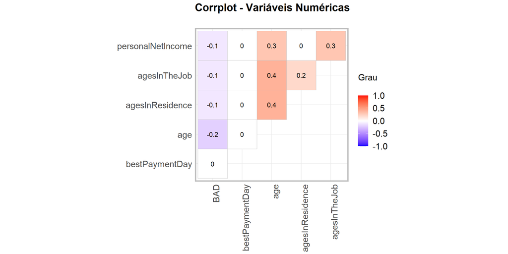

```r
# Grafico de corrplot para analise

ggcorrplot::ggcorrplot(corr = as.data.frame(stats::cor(CreditScoring %>%
                                                         dplyr::select(c(BAD, age, agesInResidence, agesInTheJob,
                                                                         bestPaymentDay, personalNetIncome)) %>%
                                                         tidyr:: drop_na()), method = "pearson",
                       use = "complete.obs", na.rm = TRUE),
                       lab_size = 4, type = "upper", hc.order = TRUE,
                       lab = TRUE, legend.title = "\nGrau\n", digits = 1) +
  ggplot2::labs(title = "Corrplot - Variáveis Numéricas\n") +
  ggplot2:: theme(plot.title = element_text(size = 18.0, face = "bold"),
                  legend.text = element_text(size = 15.0),
                  legend.title = element_text(size = 15.0),
                  axis.text.x = element_text(size = 15, angle = 90),
                  axis.text.y = element_text(size = 15),
                  panel.border = element_rect(colour = "grey", fill = NA, size = 2))
```

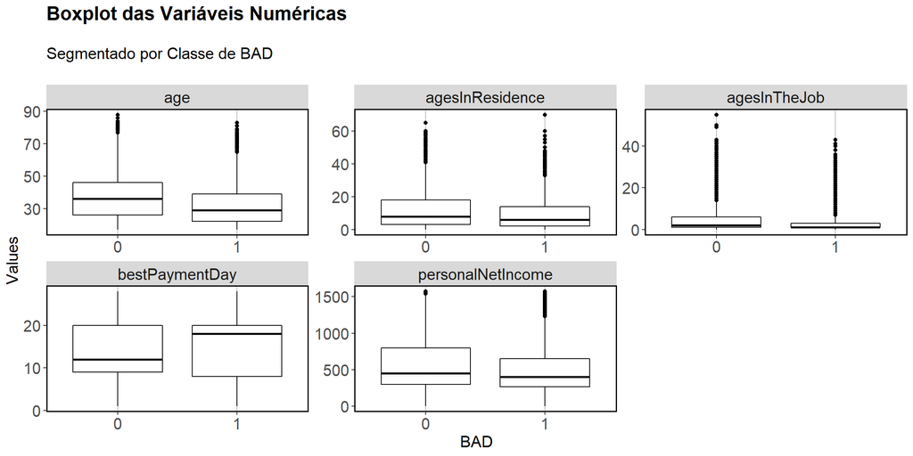

```r
# Grafico de boxplot para analise

ggplot2::ggplot(CreditScoring %>%
                  dplyr::select(c(BAD, age, agesInResidence, agesInTheJob,
                                  bestPaymentDay, personalNetIncome)) %>%
                  tidyr::pivot_longer(cols = !c(BAD), names_to = "Variables", values_to = "Values"),
                aes(x = as.factor(BAD), y = Values)) +
  geom_boxplot(colour = 'Black') +
  ggplot2::xlab('BAD') +
  ggplot2::labs(title = "Boxplot das Variáveis Numéricas",
                subtitle = "\nSegmentado por Classe de BAD\n") +
  ggplot2::theme(panel.background = element_rect(fill = "white"),
                 panel.grid.major.x = element_line(colour = "grey"),
                 plot.title = element_text(size = 18.0, face = "bold"),
                 plot.subtitle = element_text(size = 15.0),
                 panel.border = element_rect(colour = "black", fill = NA, size = 1),
                 axis.text.x = element_text(angle = 0, size = 15.0),
                 axis.text.y = element_text(size = 15.0),
                 axis.title.x = element_text(size = 15.0),
                 axis.title.y = element_text(size = 15.0),
                 strip.text = element_text(size = 15)) +
  ggplot2::facet_wrap(~ Variables, scales = 'free')
```

*Comments*: Visualizando os gráficos obtidos, analisamos alguns comportamentos em relação à BAD:  
a) Nenhuma variável numérica é relativamente discriminante em relação ao target;  
b) Há uma fraca tendência de quanto menor a idade/anos na residência/anos no trabalho/renda pessoal, mais o cliente tende a ser 1;  
c) O melhor dia de pagamento não varia a distribuição, mas apresenta medianas distintas;

**Variáveis Categóricas**

```r
# Criando funcao para plot do share de cada classe em relacao ao target

sharePlot <- function(vars){

  plot <- ggplot2::ggplot(CreditScoring %>%
                  dplyr::select(c(vars, 'BAD')) %>%
                  tidyr::pivot_longer(cols = !c(BAD), names_to = "Variables", values_to = "Values") %>%
                  dplyr::count(BAD, Variables, Values) %>%
                  dplyr::group_by(Variables, Values) %>%
                  dplyr::mutate(prop = n/sum(n)),
                aes(x = as.factor(BAD), y = prop)) +
  ggplot2::geom_col(color = 'black') +
  ggplot2::scale_y_continuous(labels = scales::percent, n.breaks = 5) +
  ggplot2::xlab('Classes') +
  ggplot2::ylab('Porcentagem do Total') +
  ggplot2::labs(title = "Barplot - Variáveis Categóricas",
                subtitle = "\nSegmentado por Feature e por classe\n") +
  ggplot2::theme(panel.background = element_rect(fill = "white"),
                 panel.grid.major.x = element_line(colour = "grey"),
                 plot.title = element_text(size = 14.0, face = "bold"),
                 plot.subtitle = element_text(size = 10.0),
                 panel.border = element_rect(colour = "black", fill = NA, size = 1),
                 axis.text.x = element_text(angle = 0, size = 10.0),
                 axis.text.y = element_text(size = 8.0),
                 axis.title.x = element_text(size = 10.0),
                 axis.title.y = element_text(size = 10.0),
                 strip.text = element_text(size = 8)) +
  ggplot2::facet_wrap(~ Variables+Values, scales = 'free')

  plot

}
```

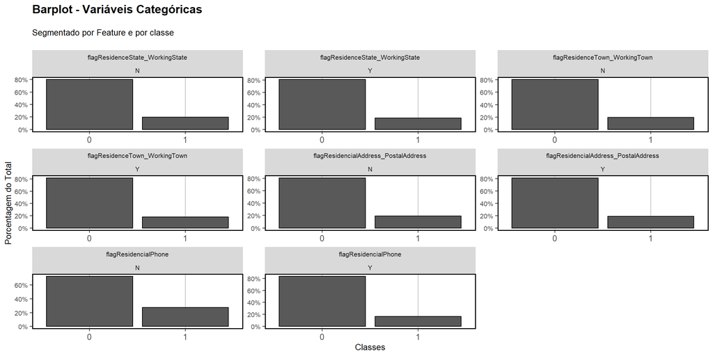

```r
# Criando plot para diferentes conjuntos de vetores

    ## 1 - Flags de Residencial

sharePlot(c('flagResidencialPhone', 'flagResidenceTown_WorkingTown',
            'flagResidenceState_WorkingState', 'flagResidencialAddress_PostalAddress'))
```

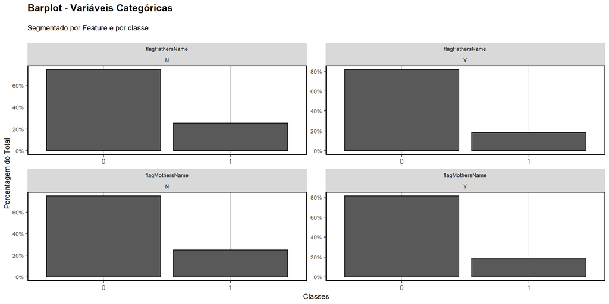

```r
    ## 2 - Flags de Name

sharePlot(c('flagMothersName', 'flagFathersName'))
```

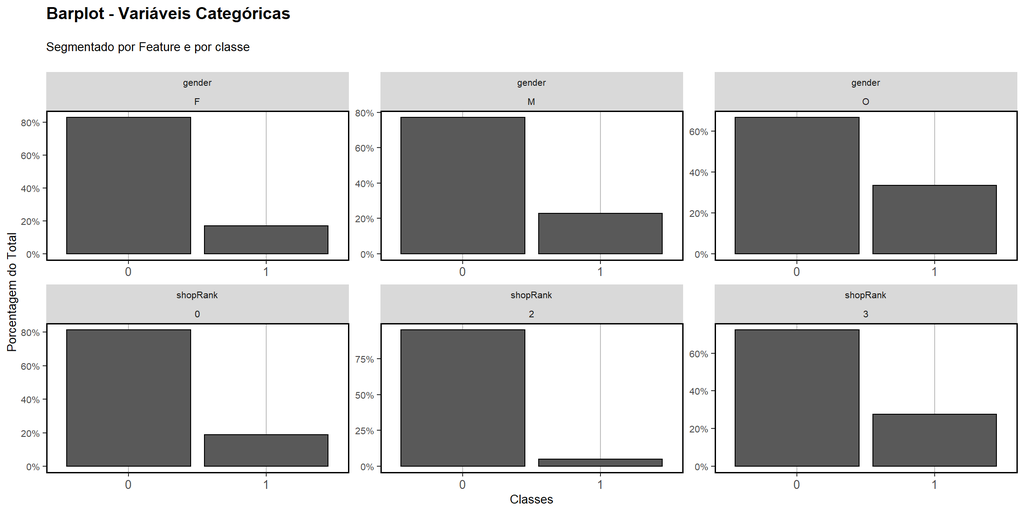

```r
    ## 3 - Classes de gender e shopRank

sharePlot(c('gender', 'shopRank'))
```

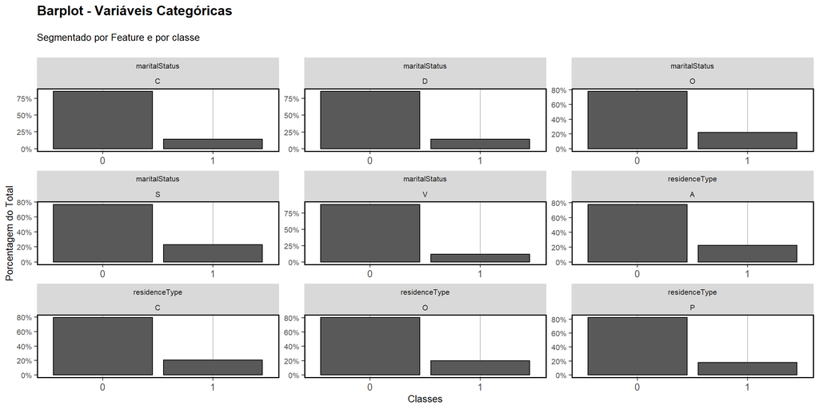

```r
    ## 4 - Classes de maritalStatus & residenceType

sharePlot(c('maritalStatus', 'residenceType'))
```

```r
# Criando outra funcao para plot do share. Agora, poderemos personalizar segundo o percentual da classe na base toda.

sharePlot2 <- function(var, p = 0.02){

  plot <- ggplot2::ggplot(CreditScoring %>%
                            dplyr::select(c(var, 'BAD')) %>%
                            dplyr::inner_join(CreditScoring %>%
                                                dplyr::select(var) %>%
                                                dplyr::count(dplyr::across(1)) %>%
                                                dplyr::mutate(prop = n/sum(n)) %>%
                                                dplyr::filter(prop > p) %>%
                                                dplyr::select(var),
                                              by = var) %>%
                            tidyr::pivot_longer(cols = !c(BAD), names_to = "Variables", values_to = "Values") %>%
                            dplyr::count(BAD, Variables, Values) %>%
                            dplyr::group_by(Values) %>%
                            dplyr::mutate(prop = n/sum(n)),
                          aes(x = as.factor(BAD), y = prop)) +
    ggplot2::geom_col(color = 'black') +
    ggplot2::scale_y_continuous(labels = scales::percent, n.breaks = 5) +
    ggplot2::xlab('Classes') +
    ggplot2::ylab('Porcentagem do Total') +
    ggplot2::labs(title = "Barplot - Variáveis Categóricas",
                  subtitle = paste0("\nSegmentado por Classe de " , var, "\n")) +
    ggplot2::theme(panel.background = element_rect(fill = "white"),
                   panel.grid.major.x = element_line(colour = "grey"),
                   plot.title = element_text(size = 18.0, face = "bold"),
                   plot.subtitle = element_text(size = 15.0),
                   panel.border = element_rect(colour = "black", fill = NA, size = 1),
                   axis.text.x = element_text(angle = 0, size = 15.0),
                   axis.text.y = element_text(size = 12.0),
                   axis.title.x = element_text(size = 15.0),
                   axis.title.y = element_text(size = 15.0),
                   strip.text = element_text(size = 10)) +
    ggplot2::facet_wrap(~ Variables+Values, scales = 'free')

  plot

}
```

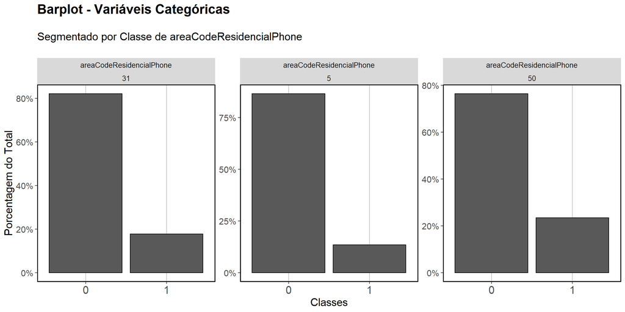

```r
# # Analisando classes mais frequentes nas variaveis areaCodeResidencialPhone & professionCode (Classe deve ser ao menos 2% da populacao total)

sharePlot2(var = 'areaCodeResidencialPhone', p = 0.02)
```

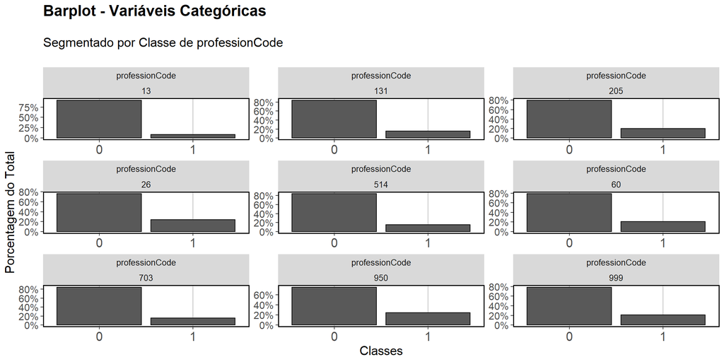

```r
sharePlot2(var = 'professionCode', p = 0.02)
```

*Comments*: O gráfico de barras gerado nos permite visualizar que:  
a) Nenhuma variável categória é relativamente discriminante em relação ao target;  
b) Algumas flags como ‘flagFathersName’, ‘flagMothersName’, ‘flagResidencialPhone’ mostram quando o cliente cadastra na plataforma tende a ser mais 0.  
c) Apesar de gênero diferenciar, não podemos utilizar essa variável para análise de crédito, pois é anti-ético.  
d) O estado civíl ‘S’ e ‘O’ tende a ser mais inadimplente do que as demais classes.  
e) E algumas features não mostram evidentes diferenciações como ‘flagResidenceState_WorkingState’, ‘flagResidenceTown_WorkingTown’, ‘flagResidencialAddress_PostalAddress’, ‘residenceType’.  
f) A variável ‘shopRank’ para a classe 2 aparenta ter poder de discriminação, mas a volumetria acaba sendo muito baixa para abrangir a população como um todo.  
g) Alguns ‘areaCodeResidencialPhone’ como 31 e 50 mostram fraca tendência a ser 1.  
h) Classes de profissão como ‘13’ e ‘514’ são mais propícios a serem 0, enquanto as profissões ‘950’ e ‘26’ tendem a ser mais 1.

## 2.6 . **Salvando base para modelo**

```r
# Salvando dado para estudo futuro

data.table::fwrite(
  x = CreditScoring,
  file = 'C:/Users/daiha/OneDrive/Documentos/R/CreditScoring_dfML.gz',
  compress = 'gzip')

# Limpando workspace

rm(list = ls())
```